# 重賞レース予測レポート【レース終了】

作成日時: 2026/05/31 17:34:18

☞ [マニュアル(pdf)](https://ryutoro-galois.github.io/keiba-predictor/manual/manual.pdf)

☞ 過去6年の同一レース結果: [2025年](https://ryutoro-galois.github.io/keiba-predictor/report/PredResult_2025y_raceDate_20250531_20250601.html), [2024年](https://ryutoro-galois.github.io/keiba-predictor/report/PredResult_2024y_raceDate_20240525_20240526.html), [2023年](https://ryutoro-galois.github.io/keiba-predictor/report/PredResult_2023y_raceDate_20230527_20230528.html), [2022年](https://ryutoro-galois.github.io/keiba-predictor/report/PredResult_2022y_raceDate_20220528_20220529.html), [2021年](https://ryutoro-galois.github.io/keiba-predictor/report/PredResult_2021y_raceDate_20210530_20210530.html), [2020年](https://ryutoro-galois.github.io/keiba-predictor/report/PredResult_2020y_raceDate_20200531_20200531.html)

☞ 過去4週間の別レース結果: [1週前(5/23-24)](https://ryutoro-galois.github.io/keiba-predictor/report/PredResult_2026y_raceDate_20260523_20260524.html), [2週前(5/16-17)](https://ryutoro-galois.github.io/keiba-predictor/report/PredResult_2026y_raceDate_20260516_20260517.html), [3週前(5/9-10)](https://ryutoro-galois.github.io/keiba-predictor/report/PredResult_2026y_raceDate_20260509_20260510.html), [4週前(5/2-3)](https://ryutoro-galois.github.io/keiba-predictor/report/PredResult_2026y_raceDate_20260502_20260503.html)

☞ netkeiba: [葵ステークス(GⅢ)](https://race.netkeiba.com/race/shutuba.html?race_id=202608031111&rf=race_list), [東京優駿(GⅠ)](https://race.netkeiba.com/race/shutuba.html?race_id=202605021211&rf=race_list), [目黒記念(GⅡ)](https://race.netkeiba.com/race/shutuba.html?race_id=202605021212&rf=race_list)

☞ レース結果(csv): [5/30-31](https://ryutoro-galois.github.io/keiba-predictor/csv/race_result_20260530_20260531.csv)

## 【レース結果(1)】人気と着順の関係

### 【葵ステークス(2026/05/30(土))】

[interactive chart not shown]

### 【東京優駿(2026/05/31(日))】

【東京優駿(GⅠ)】  
2026/05/31(日), 05_東京, 芝左2400m

[interactive chart not shown]

### 【目黒記念(2026/05/31(日))】

【目黒記念(GⅡ)】  
2026/05/31(日), 05_東京, 芝左2500m

[interactive chart not shown]

## 【レース結果(2)】コーナー通過順位

### 【葵ステークス(2026/05/30(土))】

[interactive chart not shown]

### 【東京優駿(2026/05/31(日))】

【東京優駿(GⅠ)】  
2026/05/31(日), 05_東京, 芝左2400m

[interactive chart not shown]

### 【目黒記念(2026/05/31(日))】

【目黒記念(GⅡ)】  
2026/05/31(日), 05_東京, 芝左2500m

[interactive chart not shown]

## 0. 推し馬予測 (AI予測)

### 【葵ステークス(GⅢ) 2026/05/30(土)】

- 本命(◎): 1-3着内確率(勝負強さ)が1位の馬
- 対抗(◯): 1-3着内確率が2-N位(20%程度以上)の中で予測タイムが最も速い馬
- 3番手(▲): 1-3着内確率が2-N位(20%程度以上)のでダークホース確率が最も高い馬
- 穴: ダークホース確率が上位1-M位(40%程度以上)の中で1-3着内確率が最も高い馬

| 推し馬 | 枠番 | 馬番 | 人気 | オッズ | 馬名 | 騎手 | 調教師 | 予測タイム(sec) | 1_順位 | 1-3着内確率(%) | 2_順位 | ﾀﾞｰｸﾎｰｽ確率(%) | 3_順位 |
| --- | --- | --- | --- | --- | --- | --- | --- | --- | --- | --- | --- | --- | --- |
| 本命(◎) | 3 | 5 | 2 | 4.7 | エイシンディード | 川又賢治 | 大久保龍志 | 68.1 | 3 | 44.0 | 1 | 0.4 | 15 |
| 対抗(◯) | 7 | 13 | 3 | 6.9 | タマモイカロス | 高杉吏麒 | 藤岡健一 | 68.1 | 3 | 28.7 | 2 | 0.6 | 14 |
| 3番手(▲) | 5 | 10 | 11 | 44.1 | シラヌイ | 吉村誠之助 | 高橋亮 | 68.1 | 3 | 15.2 | 5 | 35.4 | 2 |
| 穴 | 3 | 6 | 14 | 75.9 | コックピットサイト | 浜中俊 | 鹿戸雄一 | 75.2 | 12 | 1.8 | 16 | 43.9 | 1 |

### 【東京優駿(GⅠ) 2026/05/31(日)】

- 本命(◎): 1-3着内確率(勝負強さ)が1位の馬
- 対抗(◯): 1-3着内確率が2-N位(20%程度以上)の中で予測タイムが最も速い馬
- 3番手(▲): 1-3着内確率が2-N位(20%程度以上)のでダークホース確率が最も高い馬
- 穴: ダークホース確率が上位1-M位(40%程度以上)の中で1-3着内確率が最も高い馬

| 推し馬 | 枠番 | 馬番 | 人気 | オッズ | 馬名 | 騎手 | 調教師 | 予測タイム(sec) | 1_順位 | 1-3着内確率(%) | 2_順位 | ﾀﾞｰｸﾎｰｽ確率(%) | 3_順位 |
| --- | --- | --- | --- | --- | --- | --- | --- | --- | --- | --- | --- | --- | --- |
| 本命(◎) | 5 | 9 | 7 | 16.2 | アウダーシア | Ｄ．レーン | 手塚貴久 | 147.5 | 2 | 40.6 | 1 | 3.4 | 10 |
| 対抗(◯) | 8 | 17 | 1 | 2.9 | ロブチェン | 松山弘平 | 杉山晴紀 | 142.6 | 1 | 27.8 | 6 | 0.8 | 13 |
| 3番手(▲) | 3 | 5 | 11 | 30.9 | バステール | 川田将雅 | 斉藤崇史 | 149.2 | 6 | 20.8 | 10 | 37.9 | 8 |
| 穴 | 8 | 18 | 15 | 122.8 | エムズビギン | Ｆ．ゴンサルベス | 友道康夫 | 149.2 | 6 | 13.8 | 11 | 53.5 | 3 |

### 【目黒記念(GⅡ) 2026/05/31(日)】

- 本命(◎): 1-3着内確率(勝負強さ)が1位の馬
- 対抗(◯): 1-3着内確率が2-N位(20%程度以上)の中で予測タイムが最も速い馬
- 3番手(▲): 1-3着内確率が2-N位(20%程度以上)のでダークホース確率が最も高い馬
- 穴: ダークホース確率が上位1-M位(40%程度以上)の中で1-3着内確率が最も高い馬

| 推し馬 | 枠番 | 馬番 | 人気 | オッズ | 馬名 | 騎手 | 調教師 | 予測タイム(sec) | 1_順位 | 1-3着内確率(%) | 2_順位 | ﾀﾞｰｸﾎｰｽ確率(%) | 3_順位 |
| --- | --- | --- | --- | --- | --- | --- | --- | --- | --- | --- | --- | --- | --- |
| 本命(◎) | 4 | 6 | 2 | 4.2 | ウィクトルウェルス | Ｃ．ルメール | 宮田敬介 | 148.2 | 1.5 | 56.7 | 1 | 0.5 | 12 |
| 対抗(◯) | 3 | 4 | 1 | 4.1 | ファイアンクランツ | Ｄ．レーン | 堀宣行 | 148.2 | 1.5 | 47.5 | 2 | 0.4 | 14 |
| 3番手(▲) | 8 | 14 | 7 | 12.7 | キングスコール | 坂井瑠星 | 矢作芳人 | 154.7 | 3.0 | 34.0 | 3 | 1.8 | 8 |
| 穴 | 8 | 13 | 12 | 37.2 | ヴェルミセル | Ｆ．ゴンサルベス | 吉村圭司 | 160.6 | 10.0 | 11.1 | 8 | 66.0 | 1 |

## 1. 予測チャート (タイム/勝負強さ)

### 【葵ステークス(GⅢ)】

[interactive chart not shown]

### 【東京優駿(GⅠ)】

2026/05/31(日), 05_東京, 芝左2400m

[interactive chart not shown]

### 【目黒記念(GⅡ)】

2026/05/31(日), 05_東京, 芝左2500m

[interactive chart not shown]

## 2. オッズモニタリング (毎時)

### 【葵ステークス】

[interactive chart not shown]

### 【東京優駿】

[interactive chart not shown]

### 【目黒記念】

[interactive chart not shown]

## 3. 出馬表

### 【葵ステークス 2026/05/30(土) 】

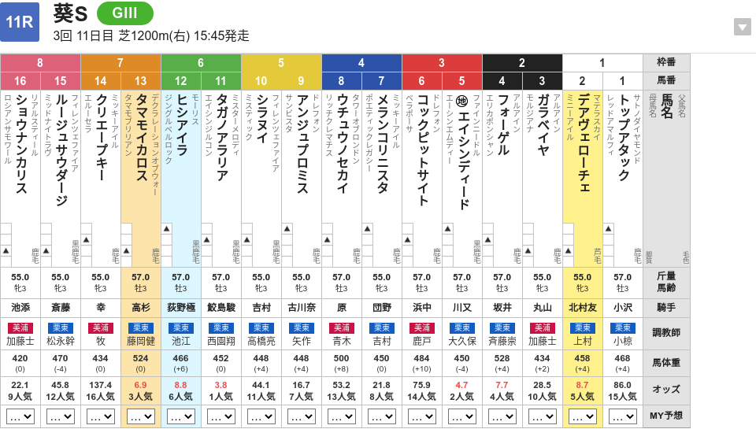

### 【東京優駿 2026/05/31(日) 】

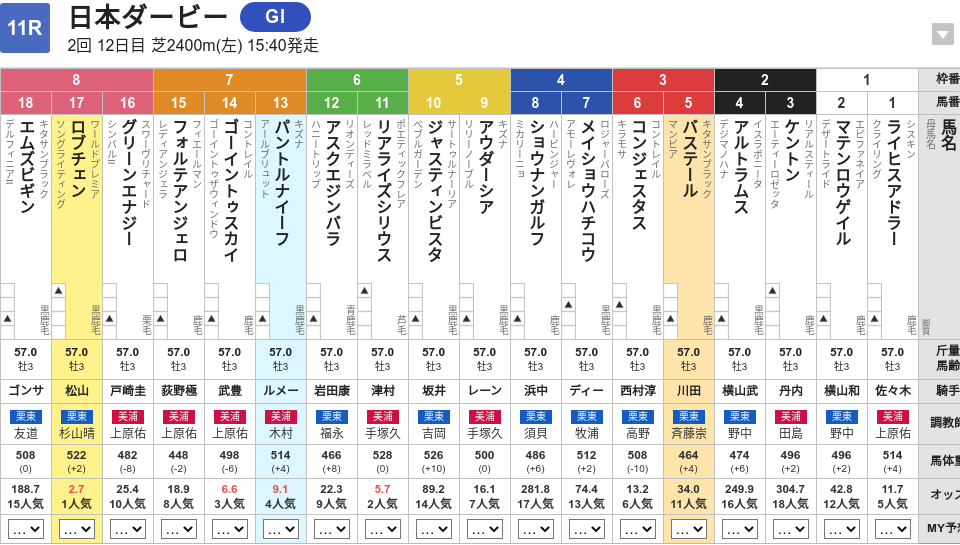

### 【目黒記念 2026/05/31(日) 】

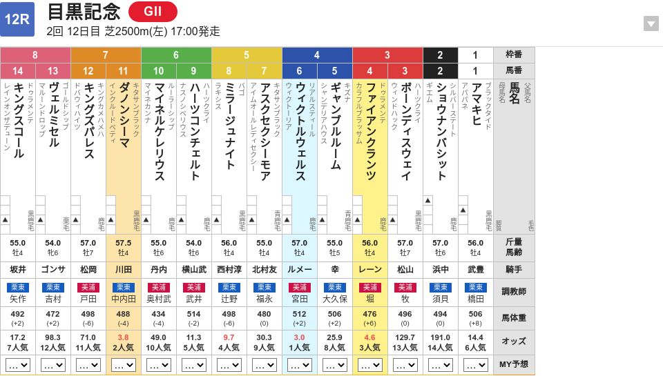

## 4. 単勝予測結果

### 【葵ステークス(GⅢ) 2026/05/30(土)】

| 枠番 | 馬番 | 人気 | オッズ | 馬名 | 騎手 | 調教師 | 予測タイム(sec) | 1_順位 | 1-3着内確率(%) | 2_順位 | ﾀﾞｰｸﾎｰｽ確率(%) | 3_順位 |
| --- | --- | --- | --- | --- | --- | --- | --- | --- | --- | --- | --- | --- |
| 1 | 1 | 15 | 86.0 | トップアタック | 小沢大仁 | 小椋研介 | 73.9 | 8 | 2.6 | 14 | 10.0 | 7 |
| 1 | 2 | 5 | 8.7 | デアヴェローチェ | 北村友一 | 上村洋行 | 75.2 | 13 | 9.3 | 9 | 0.9 | 11 |
| 2 | 3 | 10 | 28.5 | ガラベイヤ | 丸山元気 | 加藤士津八 | 75.3 | 14 | 3.2 | 12 | 17.3 | 4 |
| 2 | 4 | 4 | 7.7 | フォーゲル | 坂井瑠星 | 斉藤崇史 | 74.3 | 11 | 10.3 | 8 | 0.8 | 12 |
| 3 | 5 | 2 | 4.7 | エイシンディード | 川又賢治 | 大久保龍志 | 68.1 | 3 | 44.0 | 1 | 0.4 | 15 |
| 3 | 6 | 14 | 75.9 | コックピットサイト | 浜中俊 | 鹿戸雄一 | 75.2 | 12 | 1.8 | 16 | 43.9 | 1 |
| 4 | 7 | 8 | 21.8 | メランコリニスタ | 団野大成 | 吉村圭司 | 73.7 | 7 | 3.7 | 11 | 0.8 | 13 |
| 4 | 8 | 13 | 53.2 | ウチュウノセカイ | 原優介 | 青木孝文 | 74.1 | 10 | 2.3 | 15 | 8.2 | 8 |
| 5 | 9 | 7 | 16.7 | アンジュプロミス | 古川奈穂 | 矢作芳人 | 75.4 | 15 | 7.4 | 10 | 1.2 | 9 |
| 5 | 10 | 11 | 44.1 | シラヌイ | 吉村誠之助 | 高橋亮 | 68.1 | 3 | 15.2 | 5 | 35.4 | 2 |

[output cut: 6 more lines]

### 【東京優駿(GⅠ) 2026/05/31(日)】

| 枠番 | 馬番 | 人気 | オッズ | 馬名 | 騎手 | 調教師 | 予測タイム(sec) | 1_順位 | 1-3着内確率(%) | 2_順位 | ﾀﾞｰｸﾎｰｽ確率(%) | 3_順位 |
| --- | --- | --- | --- | --- | --- | --- | --- | --- | --- | --- | --- | --- |
| 1 | 1 | 6 | 11.3 | ライヒスアドラー | 佐々木大輔 | 上原佑紀 | 149.9 | 13.5 | 27.9 | 5 | 0.6 | 17.0 |
| 1 | 2 | 12 | 43.9 | マテンロウゲイル | 横山和生 | 野中賢二 | 149.2 | 6.0 | 9.8 | 17 | 46.1 | 4.0 |
| 2 | 3 | 18 | 208.5 | ケントン | 丹内祐次 | 田島俊明 | 151.3 | 18.0 | 5.3 | 18 | 26.2 | 9.0 |
| 2 | 4 | 16 | 173.1 | アルトラムス | 横山武史 | 野中賢二 | 149.0 | 4.0 | 13.3 | 12 | 58.0 | 2.0 |
| 3 | 5 | 11 | 30.9 | バステール | 川田将雅 | 斉藤崇史 | 149.2 | 6.0 | 20.8 | 10 | 37.9 | 8.0 |
| 3 | 6 | 5 | 10.7 | コンジェスタス | 西村淳也 | 高野友和 | 150.1 | 17.0 | 28.4 | 4 | 0.6 | 18.0 |
| 4 | 7 | 13 | 51.8 | メイショウハチコウ | Ｍ．ディー | 牧浦充徳 | 149.9 | 13.5 | 11.6 | 15 | 41.6 | 6.0 |
| 4 | 8 | 17 | 181.0 | ショウナンガルフ | 浜中俊 | 須貝尚介 | 149.9 | 13.5 | 11.5 | 16 | 58.8 | 1.0 |
| 5 | 9 | 7 | 16.2 | アウダーシア | Ｄ．レーン | 手塚貴久 | 147.5 | 2.0 | 40.6 | 1 | 3.4 | 10.0 |
| 5 | 10 | 14 | 70.5 | ジャスティンビスタ | 坂井瑠星 | 吉岡辰弥 | 149.9 | 13.5 | 12.0 | 14 | 45.7 | 5.0 |

[output cut: 8 more lines]

### 【目黒記念(GⅡ) 2026/05/31(日)】

| 枠番 | 馬番 | 人気 | オッズ | 馬名 | 騎手 | 調教師 | 予測タイム(sec) | 1_順位 | 1-3着内確率(%) | 2_順位 | ﾀﾞｰｸﾎｰｽ確率(%) | 3_順位 |
| --- | --- | --- | --- | --- | --- | --- | --- | --- | --- | --- | --- | --- |
| 1 | 1 | 6 | 12.0 | アマキヒ | 武豊 | 橋田宜長 | 155.4 | 4.0 | 24.5 | 4 | 1.2 | 10 |
| 2 | 2 | 14 | 90.1 | ショウナンバシット | 浜中俊 | 須貝尚介 | 162.2 | 14.0 | 2.6 | 13 | 17.3 | 6 |
| 3 | 3 | 13 | 81.4 | ボーンディスウェイ | 松山弘平 | 牧光二 | 158.4 | 6.0 | 3.4 | 12 | 23.6 | 5 |
| 3 | 4 | 1 | 4.1 | ファイアンクランツ | Ｄ．レーン | 堀宣行 | 148.2 | 1.5 | 47.5 | 2 | 0.4 | 14 |
| 4 | 5 | 8 | 19.6 | ギャンブルルーム | 幸英明 | 大久保龍志 | 160.7 | 11.0 | 9.8 | 9 | 41.8 | 2 |
| 4 | 6 | 2 | 4.2 | ウィクトルウェルス | Ｃ．ルメール | 宮田敬介 | 148.2 | 1.5 | 56.7 | 1 | 0.5 | 12 |
| 5 | 7 | 9 | 28.2 | アスクセクシーモア | 北村友一 | 福永祐一 | 160.3 | 8.0 | 9.2 | 10 | 41.7 | 3 |
| 5 | 8 | 5 | 10.9 | ミラージュナイト | 西村淳也 | 辻野泰之 | 160.5 | 9.0 | 17.2 | 7 | 1.1 | 11 |
| 6 | 9 | 4 | 9.4 | ハーツコンチェルト | 横山武史 | 武井亮 | 155.4 | 5.0 | 20.2 | 6 | 1.8 | 9 |
| 6 | 10 | 10 | 34.1 | マイネルケレリウス | 丹内祐次 | 奥村武 | 160.7 | 12.0 | 7.1 | 11 | 38.2 | 4 |

[output cut: 4 more lines]

## 5. 人気と着順の乖離率推移

### 【東京優駿_1990y_2019y】

[interactive chart not shown]

### 【目黒記念_1990y_2019y】

[interactive chart not shown]

### 【東京優駿_1990y_2019y】

| No | 開催年 | 不整合率(%) | 頭数 | 人気別着順(1-3位) | 人気別着順(全体) |
| --- | --- | --- | --- | --- | --- |
| 30 | 2019 | 50.5 | 18頭 | 12-3-2 | 12\|3\|2\|1\|13\|7\|5\|11\|15\|10\|18\|14\|17\|16\|6\|9\|8\|4 |
| 29 | 2018 | 46.4 | 18頭 | 5-4-16 | 5\|4\|16\|13\|2\|1\|7\|6\|17\|10\|14\|3\|12\|9\|15\|8\|11\|18 |
| 28 | 2017 | 28.5 | 18頭 | 2-3-1 | 2\|3\|1\|14\|4\|7\|6\|16\|11\|5\|8\|15\|9\|10\|12\|17\|13\|18 |
| 27 | 2016 | 39.5 | 18頭 | 3-2-1 | 3\|2\|1\|7\|4\|5\|10\|12\|8\|11\|9\|13\|6\|16\|15\|14\|18\|17 |
| 26 | 2015 | 27.7 | 18頭 | 1-5-3 | 1\|5\|3\|2\|16\|9\|7\|15\|4\|10\|13\|8\|17\|6\|14\|18\|11\|12 |
| 25 | 2014 | 38.7 | 16頭 | 3-1-12 | 3\|1\|12\|16\|2\|9\|10\|6\|15\|8\|11\|4\|7\|14\|17\|5 |
| 24 | 2013 | 24.4 | 18頭 | 1-3-8 | 1\|3\|8\|13\|2\|14\|17\|10\|4\|11\|6\|9\|5\|16\|7\|15\|12\|18 |
| 23 | 2012 | 41.1 | 18頭 | 3-5-7 | 3\|5\|7\|1\|2\|10\|16\|13\|12\|4\|15\|17\|8\|9\|14\|11\|18\|6 |
| 22 | 2011 | 29.3 | 17頭 | 1-10-8 | 1\|10\|8\|4\|9\|14\|2\|15\|5\|11\|7\|3\|13\|6\|12\|18\|16 |
| 21 | 2010 | 35.4 | 17頭 | 7-5-1 | 7\|5\|1\|12\|4\|2\|10\|15\|3\|11\|9\|8\|6\|14\|17\|13\|16 |

[output cut: 20 more lines]

### 【目黒記念_1990y_2019y】

| No | 開催年 | 不整合率(%) | 頭数 | 人気別着順(1-3位) | 人気別着順(全体) |
| --- | --- | --- | --- | --- | --- |
| 30 | 2019 | 60.1 | 12頭 | 3-5-9 | 3\|5\|9\|6\|2\|8\|10\|1\|12\|4\|13\|7 |
| 29 | 2018 | 39.0 | 16頭 | 9-10-1 | 9\|10\|1\|6\|8\|3\|14\|13\|16\|7\|2\|5\|4\|12\|15\|11 |
| 28 | 2017 | 39.8 | 18頭 | 8-1-13 | 8\|1\|13\|6\|17\|11\|4\|3\|2\|7\|5\|16\|15\|18\|12\|9\|10\|14 |
| 27 | 2016 | 36.5 | 18頭 | 3-1-8 | 3\|1\|8\|6\|4\|2\|5\|7\|11\|13\|9\|10\|15\|16\|12\|17\|18\|14 |
| 26 | 2015 | 29.6 | 18頭 | 11-4-1 | 11\|4\|1\|6\|15\|2\|10\|7\|3\|12\|17\|5\|8\|9\|14\|16\|13\|18 |
| 25 | 2014 | 42.2 | 16頭 | 8-12-4 | 8\|12\|4\|2\|1\|7\|5\|3\|9\|11\|15\|6\|13\|10\|14\|16 |
| 24 | 2013 | 47.2 | 18頭 | 4-2-3 | 4\|2\|3\|14\|5\|10\|13\|7\|9\|1\|6\|8\|16\|11\|17\|12\|15\|18 |
| 23 | 2012 | 36.0 | 18頭 | 1-7-6 | 1\|7\|6\|5\|4\|13\|2\|12\|3\|15\|16\|11\|18\|10\|8\|14\|17\|9 |
| 22 | 2011 | 34.4 | 17頭 | 7-1-6 | 7\|1\|6\|4\|5\|17\|11\|2\|8\|15\|12\|10\|3\|9\|16\|13\|14 |
| 21 | 2010 | 68.6 | 12頭 | 5-9-7 | 5\|9\|7\|6\|2\|4\|8\|3\|1\|11\|10\|12 |

[output cut: 20 more lines]

## 6. 1-3番人気馬の着順分類予測

### 【東京優駿】

| 分類 | 凡例 | 発生確率(%) | 当該レース | 当該レースランク | 直近1年間 |
| --- | --- | --- | --- | --- | --- |
| 4: 1,2番人気のみ (4_pop12) | 1 \| 2 \| * | 18.1 | 2.18 | 2.18 | 0.00 |
| 1: 1番人気のみ (1_pop1) | 1 \| * \| * | 15.9 | 0.82 | 0.82 | 0.00 |
| 5: 1,3番人気のみ (5_pop13) | 1 \| 3 \| * | 15.1 | 0.54 | 0.54 | 0.00 |
| 8: 1,2,3番人気すべて着外 (8_darkhorse) | * \| * \| * | 11.8 | 2.11 | 2.11 | 0.00 |
| 6: 2,3番人気のみ (6_pop23) | 2 \| 3 \| * | 11.0 | 0.57 | 0.57 | 0.22 |
| 2: 2番人気のみ (2_pop2) | 2 \| * \| * | 10.3 | 3.68 | 3.68 | 0.00 |
| 3: 3番人気のみ (3_pop3) | 3 \| * \| * | 9.3 | 1.66 | 1.66 | 0.19 |
| 7: 1,2,3番人気すべて着内 (7_pop123) | 1 \| 2 \| 3 | 8.4 | 0.76 | 0.76 | 0.00 |

### 【目黒記念】

| 分類 | 凡例 | 発生確率(%) | 当該レース | 当該レースランク | 直近1年間 |
| --- | --- | --- | --- | --- | --- |
| 4: 1,2番人気のみ (4_pop12) | 1 \| 2 \| * | 17.7 | 3.16 | 3.16 | 0.00 |
| 1: 1番人気のみ (1_pop1) | 1 \| * \| * | 17.6 | 0.63 | 0.63 | 0.00 |
| 5: 1,3番人気のみ (5_pop13) | 1 \| 3 \| * | 13.5 | 1.22 | 1.22 | 0.00 |
| 3: 3番人気のみ (3_pop3) | 3 \| * \| * | 13.1 | 0.43 | 0.43 | 0.26 |
| 8: 1,2,3番人気すべて着外 (8_darkhorse) | * \| * \| * | 13.1 | 2.34 | 2.34 | 0.00 |
| 2: 2番人気のみ (2_pop2) | 2 \| * \| * | 9.4 | 3.36 | 3.36 | 0.00 |
| 6: 2,3番人気のみ (6_pop23) | 2 \| 3 \| * | 8.6 | 0.62 | 0.62 | 0.17 |
| 7: 1,2,3番人気すべて着内 (7_pop123) | 1 \| 2 \| 3 | 7.1 | 2.54 | 2.54 | 0.00 |

## 7. 3連複予測結果

### 【葵ステークス(GⅢ) 2026/05/30(土)】

| 分類 | 馬番 | 枠番 | 人気 | 平均予測タイム(sec) | 1-3着内確率(%) | ﾀﾞｰｸﾎｰｽ確率(%) | 馬名 | 騎手 | 調教師 |
| --- | --- | --- | --- | --- | --- | --- | --- | --- | --- |
| 7: 1,2,3番人気すべて着内 (7_pop123) | 11-5-13 | 6-3-7 | 1-2-3 | 68.10 | 2.31 | 0.00 | タガノアラリア \| エイシンディード \| タマモイカロス | 鮫島克駿 \| 川又賢治 \| 高杉吏麒 | 西園翔太 \| 大久保龍志 \| 藤岡健一 |
| 6: 2,3番人気のみ (6_pop23) | 5-13-12 | 3-7-6 | 2-3-6 | 69.63 | 2.16 | 0.00 | エイシンディード \| タマモイカロス \| ヒシアイラ | 川又賢治 \| 高杉吏麒 \| 荻野極 | 大久保龍志 \| 藤岡健一 \| 池江泰寿 |
| 6: 2,3番人気のみ (6_pop23) | 5-13-10 | 3-7-5 | 2-3-11 | 68.10 | 1.92 | 0.00 | エイシンディード \| タマモイカロス \| シラヌイ | 川又賢治 \| 高杉吏麒 \| 吉村誠之助 | 大久保龍志 \| 藤岡健一 \| 高橋亮 |
| 6: 2,3番人気のみ (6_pop23) | 5-13-15 | 3-7-8 | 2-3-12 | 70.57 | 1.79 | 0.00 | エイシンディード \| タマモイカロス \| ルージュサウダージ | 川又賢治 \| 高杉吏麒 \| 斎藤新 | 大久保龍志 \| 藤岡健一 \| 松永幹夫 |
| 6: 2,3番人気のみ (6_pop23) | 5-13-16 | 3-7-8 | 2-3-9 | 68.10 | 1.49 | 0.00 | エイシンディード \| タマモイカロス \| ショウナンカリス | 川又賢治 \| 高杉吏麒 \| 池添謙一 | 大久保龍志 \| 藤岡健一 \| 加藤士津八 |
| 4: 1,2番人気のみ (4_pop12) | 11-5-12 | 6-3-6 | 1-2-6 | 69.63 | 1.38 | 0.00 | タガノアラリア \| エイシンディード \| ヒシアイラ | 鮫島克駿 \| 川又賢治 \| 荻野極 | 西園翔太 \| 大久保龍志 \| 池江泰寿 |
| 6: 2,3番人気のみ (6_pop23) | 5-13-4 | 3-7-2 | 2-3-4 | 70.17 | 1.30 | 0.00 | エイシンディード \| タマモイカロス \| フォーゲル | 川又賢治 \| 高杉吏麒 \| 坂井瑠星 | 大久保龍志 \| 藤岡健一 \| 斉藤崇史 |
| 4: 1,2番人気のみ (4_pop12) | 11-5-10 | 6-3-5 | 1-2-11 | 68.10 | 1.22 | 0.00 | タガノアラリア \| エイシンディード \| シラヌイ | 鮫島克駿 \| 川又賢治 \| 吉村誠之助 | 西園翔太 \| 大久保龍志 \| 高橋亮 |
| 6: 2,3番人気のみ (6_pop23) | 5-13-2 | 3-7-1 | 2-3-5 | 70.47 | 1.17 | 0.00 | エイシンディード \| タマモイカロス \| デアヴェローチェ | 川又賢治 \| 高杉吏麒 \| 北村友一 | 大久保龍志 \| 藤岡健一 \| 上村洋行 |
| 4: 1,2番人気のみ (4_pop12) | 11-5-15 | 6-3-8 | 1-2-12 | 70.57 | 1.14 | 0.00 | タガノアラリア \| エイシンディード \| ルージュサウダージ | 鮫島克駿 \| 川又賢治 \| 斎藤新 | 西園翔太 \| 大久保龍志 \| 松永幹夫 |

[output cut: 550 more lines]

### 【東京優駿(GⅠ) 2026/05/31(日)】

| 分類 | 馬番 | 枠番 | 人気 | 平均予測タイム(sec) | 1-3着内確率(%) | ﾀﾞｰｸﾎｰｽ確率(%) | 馬名 | 騎手 | 調教師 |
| --- | --- | --- | --- | --- | --- | --- | --- | --- | --- |
| 8: 1,2,3番人気すべて着外 (8_darkhorse) | 13-9-15 | 7-5-7 | 4-7-8 | 149.10 | 3.87 | 0.00 | パントルナイーフ \| アウダーシア \| フォルテアンジェロ | Ｃ．ルメール \| Ｄ．レーン \| 荻野極 | 木村哲也 \| 手塚貴久 \| 上原佑紀 |
| 8: 1,2,3番人気すべて着外 (8_darkhorse) | 6-9-15 | 3-5-7 | 5-7-8 | 149.17 | 3.79 | 0.00 | コンジェスタス \| アウダーシア \| フォルテアンジェロ | 西村淳也 \| Ｄ．レーン \| 荻野極 | 高野友和 \| 手塚貴久 \| 上原佑紀 |
| 8: 1,2,3番人気すべて着外 (8_darkhorse) | 1-9-15 | 1-5-7 | 6-7-8 | 149.10 | 3.73 | 0.00 | ライヒスアドラー \| アウダーシア \| フォルテアンジェロ | 佐々木大輔 \| Ｄ．レーン \| 荻野極 | 上原佑紀 \| 手塚貴久 \| 上原佑紀 |
| 1: 1番人気のみ (1_pop1) | 17-9-15 | 8-5-7 | 1-7-8 | 146.67 | 3.71 | 0.00 | ロブチェン \| アウダーシア \| フォルテアンジェロ | 松山弘平 \| Ｄ．レーン \| 荻野極 | 杉山晴紀 \| 手塚貴久 \| 上原佑紀 |
| 8: 1,2,3番人気すべて着外 (8_darkhorse) | 9-15-12 | 5-7-6 | 7-8-9 | 149.03 | 3.50 | 0.00 | アウダーシア \| フォルテアンジェロ \| アスクエジンバラ | Ｄ．レーン \| 荻野極 \| 岩田康誠 | 手塚貴久 \| 上原佑紀 \| 福永祐一 |
| 2: 2番人気のみ (2_pop2) | 14-9-15 | 7-5-7 | 2-7-8 | 148.60 | 3.46 | 0.00 | ゴーイントゥスカイ \| アウダーシア \| フォルテアンジェロ | 武豊 \| Ｄ．レーン \| 荻野極 | 上原佑紀 \| 手塚貴久 \| 上原佑紀 |
| 8: 1,2,3番人気すべて着外 (8_darkhorse) | 13-6-9 | 7-3-5 | 4-5-7 | 149.17 | 3.34 | 0.00 | パントルナイーフ \| コンジェスタス \| アウダーシア | Ｃ．ルメール \| 西村淳也 \| Ｄ．レーン | 木村哲也 \| 高野友和 \| 手塚貴久 |
| 3: 3番人気のみ (3_pop3) | 11-9-15 | 6-5-7 | 3-7-8 | 149.00 | 3.33 | 0.00 | リアライズシリウス \| アウダーシア \| フォルテアンジェロ | 津村明秀 \| Ｄ．レーン \| 荻野極 | 手塚貴久 \| 手塚貴久 \| 上原佑紀 |
| 8: 1,2,3番人気すべて着外 (8_darkhorse) | 13-1-9 | 7-1-5 | 4-6-7 | 149.10 | 3.29 | 0.00 | パントルナイーフ \| ライヒスアドラー \| アウダーシア | Ｃ．ルメール \| 佐々木大輔 \| Ｄ．レーン | 木村哲也 \| 上原佑紀 \| 手塚貴久 |
| 1: 1番人気のみ (1_pop1) | 17-13-9 | 8-7-5 | 1-4-7 | 146.67 | 3.27 | 0.00 | ロブチェン \| パントルナイーフ \| アウダーシア | 松山弘平 \| Ｃ．ルメール \| Ｄ．レーン | 杉山晴紀 \| 木村哲也 \| 手塚貴久 |

[output cut: 806 more lines]

### 【目黒記念(GⅡ) 2026/05/31(日)】

| 分類 | 馬番 | 枠番 | 人気 | 平均予測タイム(sec) | 1-3着内確率(%) | ﾀﾞｰｸﾎｰｽ確率(%) | 馬名 | 騎手 | 調教師 |
| --- | --- | --- | --- | --- | --- | --- | --- | --- | --- |
| 4: 1,2番人気のみ (4_pop12) | 4-6-14 | 3-4-8 | 1-2-7 | 150.37 | 9.15 | 0.00 | ファイアンクランツ \| ウィクトルウェルス \| キングスコール | Ｄ．レーン \| Ｃ．ルメール \| 坂井瑠星 | 堀宣行 \| 宮田敬介 \| 矢作芳人 |
| 4: 1,2番人気のみ (4_pop12) | 4-6-1 | 3-4-1 | 1-2-6 | 150.60 | 6.60 | 0.00 | ファイアンクランツ \| ウィクトルウェルス \| アマキヒ | Ｄ．レーン \| Ｃ．ルメール \| 武豊 | 堀宣行 \| 宮田敬介 \| 橋田宜長 |
| 7: 1,2,3番人気すべて着内 (7_pop123) | 4-6-11 | 3-4-7 | 1-2-3 | 152.03 | 5.58 | 0.00 | ファイアンクランツ \| ウィクトルウェルス \| ダノンシーマ | Ｄ．レーン \| Ｃ．ルメール \| 川田将雅 | 堀宣行 \| 宮田敬介 \| 中内田充正 |
| 4: 1,2番人気のみ (4_pop12) | 4-6-9 | 3-4-6 | 1-2-4 | 150.60 | 5.43 | 0.00 | ファイアンクランツ \| ウィクトルウェルス \| ハーツコンチェルト | Ｄ．レーン \| Ｃ．ルメール \| 横山武史 | 堀宣行 \| 宮田敬介 \| 武井亮 |
| 2: 2番人気のみ (2_pop2) | 6-1-14 | 4-1-8 | 2-6-7 | 152.77 | 4.73 | 0.00 | ウィクトルウェルス \| アマキヒ \| キングスコール | Ｃ．ルメール \| 武豊 \| 坂井瑠星 | 宮田敬介 \| 橋田宜長 \| 矢作芳人 |
| 4: 1,2番人気のみ (4_pop12) | 4-6-8 | 3-4-5 | 1-2-5 | 152.30 | 4.62 | 0.00 | ファイアンクランツ \| ウィクトルウェルス \| ミラージュナイト | Ｄ．レーン \| Ｃ．ルメール \| 西村淳也 | 堀宣行 \| 宮田敬介 \| 辻野泰之 |
| 6: 2,3番人気のみ (6_pop23) | 6-11-14 | 4-7-8 | 2-3-7 | 154.20 | 4.00 | 0.00 | ウィクトルウェルス \| ダノンシーマ \| キングスコール | Ｃ．ルメール \| 川田将雅 \| 坂井瑠星 | 宮田敬介 \| 中内田充正 \| 矢作芳人 |
| 1: 1番人気のみ (1_pop1) | 4-1-14 | 3-1-8 | 1-6-7 | 152.77 | 3.96 | 0.00 | ファイアンクランツ \| アマキヒ \| キングスコール | Ｄ．レーン \| 武豊 \| 坂井瑠星 | 堀宣行 \| 橋田宜長 \| 矢作芳人 |
| 2: 2番人気のみ (2_pop2) | 6-9-14 | 4-6-8 | 2-4-7 | 152.77 | 3.89 | 0.00 | ウィクトルウェルス \| ハーツコンチェルト \| キングスコール | Ｃ．ルメール \| 横山武史 \| 坂井瑠星 | 宮田敬介 \| 武井亮 \| 矢作芳人 |
| 5: 1,3番人気のみ (5_pop13) | 4-11-14 | 3-7-8 | 1-3-7 | 154.20 | 3.35 | 0.00 | ファイアンクランツ \| ダノンシーマ \| キングスコール | Ｄ．レーン \| 川田将雅 \| 坂井瑠星 | 堀宣行 \| 中内田充正 \| 矢作芳人 |

[output cut: 354 more lines]

## 8. 直近の全レース情報

[output not shown]

[output cut: 5 more lines]